# chp_9_plots

### Histograms and Density Plots

A histogram is like a bar plot that gives a display of value frequency. The data points are split into discrete evenly spaced bins.

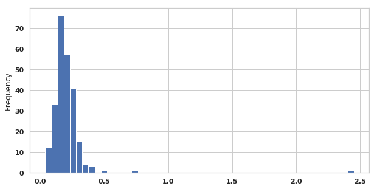

```python
tips['tip_pct'].plot.hist(bins=50);
```

A related plot type is a *density plot*, which is an estimate of continuous probability distribution that might have enerated the observed data. They are also known as `KDE` (Kernal Density Estimate) plots.

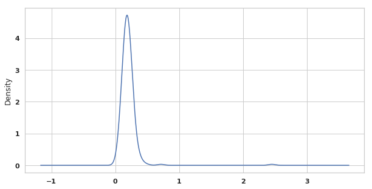

```python
tips['tip_pct'].plot.density();
```

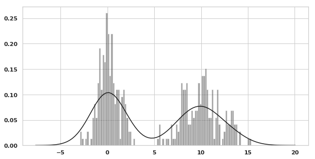

```python
comp1 = np.random.normal(0, 1, size=200)
comp2 = np.random.normal(10, 2, size=200)
values = pd.Series(np.concatenate([comp1, comp2]))
sns.distplot(values, bins=100, color='k');
```

### Scatter or Point Plots

Useful for examing the relationship between 2 one-dimensional data series.

```python
macro = pd.read_csv('macrodata.csv')
macro.head()
```

|  | year | quarter | realgdp | realcons | realinv | realgovt | realdpi | cpi | m1 | tbilrate | unemp | pop | infl | realint |
| --- | --- | --- | --- | --- | --- | --- | --- | --- | --- | --- | --- | --- | --- | --- |
| 0 | 1959.0 | 1.0 | 2710.349 | 1707.4 | 286.898 | 470.045 | 1886.9 | 28.98 | 139.7 | 2.82 | 5.8 | 177.146 | 0.00 | 0.00 |
| 1 | 1959.0 | 2.0 | 2778.801 | 1733.7 | 310.859 | 481.301 | 1919.7 | 29.15 | 141.7 | 3.08 | 5.1 | 177.830 | 2.34 | 0.74 |
| 2 | 1959.0 | 3.0 | 2775.488 | 1751.8 | 289.226 | 491.260 | 1916.4 | 29.35 | 140.5 | 3.82 | 5.3 | 178.657 | 2.74 | 1.09 |
| 3 | 1959.0 | 4.0 | 2785.204 | 1753.7 | 299.356 | 484.052 | 1931.3 | 29.37 | 140.0 | 4.33 | 5.6 | 179.386 | 0.27 | 4.06 |
| 4 | 1960.0 | 1.0 | 2847.699 | 1770.5 | 331.722 | 462.199 | 1955.5 | 29.54 | 139.6 | 3.50 | 5.2 | 180.007 | 2.31 | 1.19 |

```python
data = macro[['cpi', 'm1', 'tbilrate', 'unemp']]
transdata = np.log(data).diff().dropna()
transdata[-5:]
```

|  | cpi | m1 | tbilrate | unemp |
| --- | --- | --- | --- | --- |
| 198 | -0.007904 | 0.045361 | -0.396881 | 0.105361 |
| 199 | -0.021979 | 0.066753 | -2.277267 | 0.139762 |
| 200 | 0.002340 | 0.010286 | 0.606136 | 0.160343 |
| 201 | 0.008419 | 0.037461 | -0.200671 | 0.127339 |
| 202 | 0.008894 | 0.012202 | -0.405465 | 0.042560 |

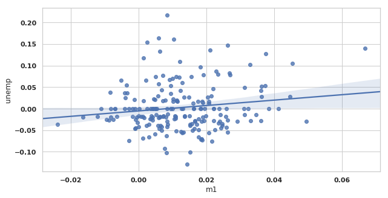

```python
sns.regplot('m1', 'unemp', data=transdata);
```

In exploratory data analysis it is important to look at scatter plots among groups of variables, known as a *scatter plot matrix*

Making such plot from scratch is a bit of work, so seaborn has the `pairplot` method.

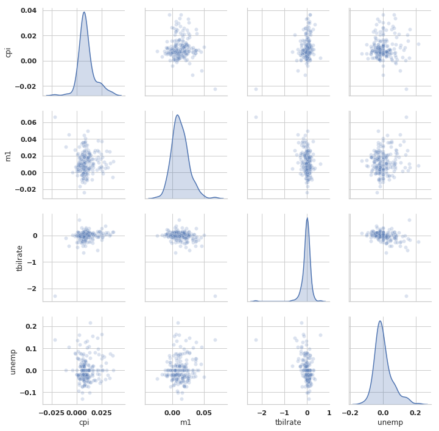

```python
sns.pairplot(transdata, diag_kind='kde', plot_kws={'alpha': 0.2})
```

`plot_kws` allows us to send config options to individual plot calls on off diagonal elements

### Facet Grids and Categorical Data

What about additional grouping dimensions? To visualise data with many categorical variables you can use a *facet grid*

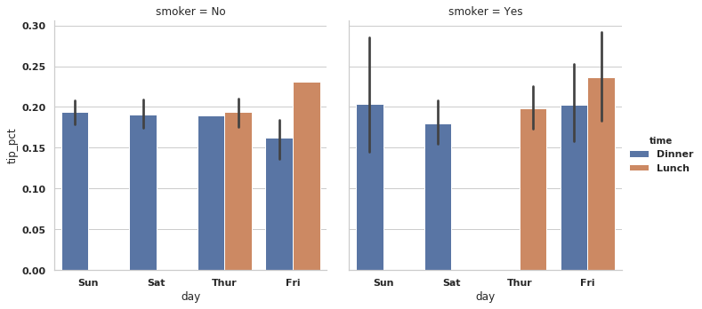

```python
sns.factorplot(x='day', y='tip_pct', hue='time', col='smoker', kind='bar', data = tips[tips.tip_pct < 1])
```

Instead of grouping by time, we can add one row per time value:

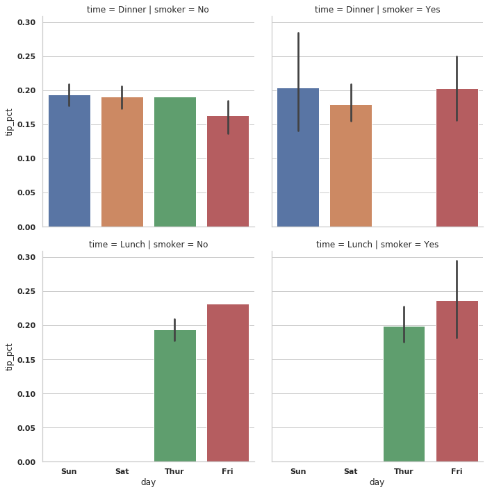

```python
sns.factorplot(x='day', y='tip_pct', row='time', col='smoker', kind='bar', data = tips[tips.tip_pct < 1]);
```

`factorplot` also supports boxplots (with median, quartiles and outliers):

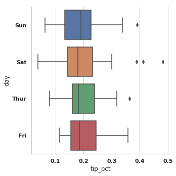

```python
sns.factorplot(x='tip_pct', y='day', kind='box', data = tips[tips.tip_pct < 0.5])
```

### Other Python Visualisation Tools

For interactive and web based plots:

- [plotly](https://plot.ly/python/)
- [bokeh](https://bokeh.pydata.org/en/latest/)